# Bellabeat Analysis Using R - A Case Study

# About Compony

A High-tech Company that manufactures health focused smart Products for women. It is small size company but they are capable enough to expand it and having potential becoame a larger player in this segment of smart technology. Urška Sršen and Sando Mur founded Bellabeat, believe that analyzing the data can open growth opportunity in market for them.

### Questions to find-

1. What are some trends in smart device usage?
2. How could these trends apply to Bellabeat customers?
3. How could these trends help influence Bellabeat marketing strategy?

### Business Task-

- To Identify potential opportunities for growth and recommendations for the Bellabeat marketing strategy improvement based on trends in smart device usage.

### Key Stackholders-

- The main stakeholders here are Urška Sršen, Bellabeat’s co-founder and Chief Creative Officer; Sando Mur, Mathematician and Bellabeat’s cofounder; And the rest of the Bellabeat marketing analytics team.

##### Installing Packages

```r
#Install Pakages

library(tidyverse)
library(lubridate)
library(ggplot2)
library(dplyr)
library(tidyr)
```

### Importing Data

Data is downloaded first then being imported from own Directory

```r
daily_activity <- read_csv("Protfolio Projects/Bellabeat Analysis/Raw Data/dailyActivity_merged.csv")
```

[output not shown]

- Let’s Check the data using Head() function

```r
head(daily_activity)
```

| Id | ActivityDate | TotalSteps | TotalDistance | TrackerDistance | LoggedActivitiesDistance | VeryActiveDistance | ModeratelyActiveDistance | LightActiveDistance | SedentaryActiveDistance | VeryActiveMinutes | FairlyActiveMinutes | LightlyActiveMinutes | SedentaryMinutes | Calories |
| --- | --- | --- | --- | --- | --- | --- | --- | --- | --- | --- | --- | --- | --- | --- |
| 1503960366 | 04-12-2016 | 13162 | 8.50 | 8.50 | 0 | 1.88 | 0.55 | 6.06 | 0 | 25 | 13 | 328 | 728 | 1985 |
| 1503960366 | 4/13/2016 | 10735 | 6.97 | 6.97 | 0 | 1.57 | 0.69 | 4.71 | 0 | 21 | 19 | 217 | 776 | 1797 |
| 1503960366 | 4/14/2016 | 10460 | 6.74 | 6.74 | 0 | 2.44 | 0.40 | 3.91 | 0 | 30 | 11 | 181 | 1218 | 1776 |
| 1503960366 | 4/15/2016 | 9762 | 6.28 | 6.28 | 0 | 2.14 | 1.26 | 2.83 | 0 | 29 | 34 | 209 | 726 | 1745 |
| 1503960366 | 4/16/2016 | 12669 | 8.16 | 8.16 | 0 | 2.71 | 0.41 | 5.04 | 0 | 36 | 10 | 221 | 773 | 1863 |
| 1503960366 | 4/17/2016 | 9705 | 6.48 | 6.48 | 0 | 3.19 | 0.78 | 2.51 | 0 | 38 | 20 | 164 | 539 | 1728 |

#### fixing the formating for Date and Time datatype

```r
#daily_activity
daily_activity$ActivityDate=as.POSIXct(daily_activity$ActivityDate, format="%m/%d/%Y", tz=Sys.timezone())
daily_activity$date <- format(daily_activity$ActivityDate, format = "%m/%d/%y")
#daily_calories
daily_calories$ActivityDay=as.POSIXct(daily_calories$ActivityDay, format="%m/%d/%Y", tz=Sys.timezone())
daily_calories$Day <- format(daily_calories$ActivityDay, format = "%m/%d/%y")
#daily_intensities
daily_intensities$ActivityDay=as.POSIXct(daily_intensities$ActivityDay, format="%m/%d/%Y", tz=Sys.timezone())
daily_intensities$Day <- format(daily_intensities$ActivityDay, format = "%m/%d/%y")
#sleep
sleep$SleepDay=as.POSIXct(sleep$SleepDay, format="%m/%d/%Y %I:%M:%S %p", tz=Sys.timezone())
sleep$date <- format(sleep$SleepDay, format = "%m/%d/%y")
```

#### Now, Formating is done for data, let’s Summarize the data

```r
n_distinct(daily_activity$Id)
```

```
[1] 33
```

```r
n_distinct(daily_calories$Id)
```

```
[1] 33
```

```r
n_distinct(daily_intensities$Id)
```

```
[1] 33
```

```r
n_distinct(sleep$Id)
```

```
[1] 24
```

```r
n_distinct(weight$Id)
```

```
[1] 8
```

Showing No. of Participants in each categories of data.

Let’s keep continue and try to find more useful information from data (Data Summary)

```r
#daily_activity
daily_activity %>%
  select(TotalSteps, TotalDistance, SedentaryMinutes, Calories) %>%
  summary()
```

```
   TotalSteps    TotalDistance    SedentaryMinutes    Calories
 Min.   :    0   Min.   : 0.000   Min.   :   0.0   Min.   :   0
 1st Qu.: 3790   1st Qu.: 2.620   1st Qu.: 729.8   1st Qu.:1828
 Median : 7406   Median : 5.245   Median :1057.5   Median :2134
 Mean   : 7638   Mean   : 5.490   Mean   : 991.2   Mean   :2304
 3rd Qu.:10727   3rd Qu.: 7.713   3rd Qu.:1229.5   3rd Qu.:2793
 Max.   :36019   Max.   :28.030   Max.   :1440.0   Max.   :4900
```

```r
#Active Minutes in daily_activity dataset
daily_activity %>%
  select(VeryActiveMinutes, FairlyActiveMinutes, LightlyActiveMinutes) %>%
  summary()
```

```
 VeryActiveMinutes FairlyActiveMinutes LightlyActiveMinutes
 Min.   :  0.00    Min.   :  0.00      Min.   :  0.0
 1st Qu.:  0.00    1st Qu.:  0.00      1st Qu.:127.0
 Median :  4.00    Median :  6.00      Median :199.0
 Mean   : 21.16    Mean   : 13.56      Mean   :192.8
 3rd Qu.: 32.00    3rd Qu.: 19.00      3rd Qu.:264.0
 Max.   :210.00    Max.   :143.00      Max.   :518.0
```

```r
#daily_calorie
daily_calories %>%
  select(Calories) %>%
  summary()
```

```
    Calories
 Min.   :   0
 1st Qu.:1828
 Median :2134
 Mean   :2304
 3rd Qu.:2793
 Max.   :4900
```

```r
#weight
weight %>%
  select(WeightKg, BMI) %>%
  summary()
```

```
    WeightKg           BMI
 Min.   : 52.60   Min.   :21.45
 1st Qu.: 61.40   1st Qu.:23.96
 Median : 62.50   Median :24.39
 Mean   : 72.04   Mean   :25.19
 3rd Qu.: 85.05   3rd Qu.:25.56
 Max.   :133.50   Max.   :47.54
```

```r
#sleep
sleep %>%
  select(TotalSleepRecords, TotalMinutesAsleep, TotalTimeInBed) %>%
  summary()
```

```
 TotalSleepRecords TotalMinutesAsleep TotalTimeInBed
 Min.   :1.000     Min.   : 58.0      Min.   : 61.0
 1st Qu.:1.000     1st Qu.:361.0      1st Qu.:403.0
 Median :1.000     Median :433.0      Median :463.0
 Mean   :1.119     Mean   :419.5      Mean   :458.6
 3rd Qu.:1.000     3rd Qu.:490.0      3rd Qu.:526.0
 Max.   :3.000     Max.   :796.0      Max.   :961.0
```

### Key Findings from this summary-

- Major of the participants are lightly active
- AVg. Sedentary time is 991 min. which needs to be reduced
- Average total steps per day are 7638 which a little bit less for having health benefits. According to the CDC research, to lower risk for all-cause mortality (or death from all causes) by 51%, 8,000 steps per day should be taken and Taking 12,000 steps per day was associated with a 65% lower risk compared with taking 4,000 steps.

## Merging Data For Analysis

Inner joining of datasets daily_activity and Sleep on Id & Date.

```r
merged_data <- merge(sleep, daily_activity, by=c('Id', 'date'))
head(merged_data)
```

|  | Id | date | SleepDay | TotalSleepRecords | TotalMinutesAsleep | TotalTimeInBed | ActivityDate | TotalSteps | TotalDistance | TrackerDistance | LoggedActivitiesDistance | VeryActiveDistance | ModeratelyActiveDistance | LightActiveDistance | SedentaryActiveDistance | VeryActiveMinutes | FairlyActiveMinutes | LightlyActiveMinutes | SedentaryMinutes | Calories | Date |
| --- | --- | --- | --- | --- | --- | --- | --- | --- | --- | --- | --- | --- | --- | --- | --- | --- | --- | --- | --- | --- | --- |
| 1 | 1503960366 | 04/13/16 | 2016-04-13 | 2 | 384 | 407 | 2016-04-13 | 10735 | 6.97 | 6.97 | 0 | 1.57 | 0.69 | 4.71 | 0 | 21 | 19 | 217 | 776 | 1797 | 04/13/16 |
| 2 | 1503960366 | 04/15/16 | 2016-04-15 | 1 | 412 | 442 | 2016-04-15 | 9762 | 6.28 | 6.28 | 0 | 2.14 | 1.26 | 2.83 | 0 | 29 | 34 | 209 | 726 | 1745 | 04/15/16 |
| 3 | 1503960366 | 04/16/16 | 2016-04-16 | 2 | 340 | 367 | 2016-04-16 | 12669 | 8.16 | 8.16 | 0 | 2.71 | 0.41 | 5.04 | 0 | 36 | 10 | 221 | 773 | 1863 | 04/16/16 |
| 4 | 1503960366 | 04/17/16 | 2016-04-17 | 1 | 700 | 712 | 2016-04-17 | 9705 | 6.48 | 6.48 | 0 | 3.19 | 0.78 | 2.51 | 0 | 38 | 20 | 164 | 539 | 1728 | 04/17/16 |
| 5 | 1503960366 | 04/19/16 | 2016-04-19 | 1 | 304 | 320 | 2016-04-19 | 15506 | 9.88 | 9.88 | 0 | 3.53 | 1.32 | 5.03 | 0 | 50 | 31 | 264 | 775 | 2035 | 04/19/16 |
| 6 | 1503960366 | 04/20/16 | 2016-04-20 | 1 | 360 | 377 | 2016-04-20 | 10544 | 6.68 | 6.68 | 0 | 1.96 | 0.48 | 4.24 | 0 | 28 | 12 | 205 | 818 | 1786 | 04/20/16 |

# Data Visualization

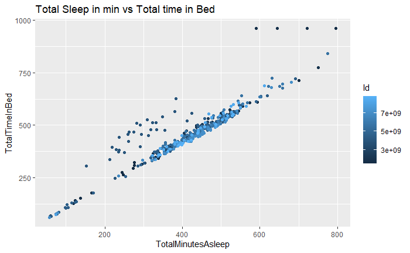

```r
#Showing trend between total Sleep and Total time in bed

ggplot(data = sleep) + geom_point(mapping = aes(x=TotalMinutesAsleep, y=TotalTimeInBed, color=Id)) + labs(title = "Total Sleep in min vs Total time in Bed")
```

- This trend shows linear relationship.

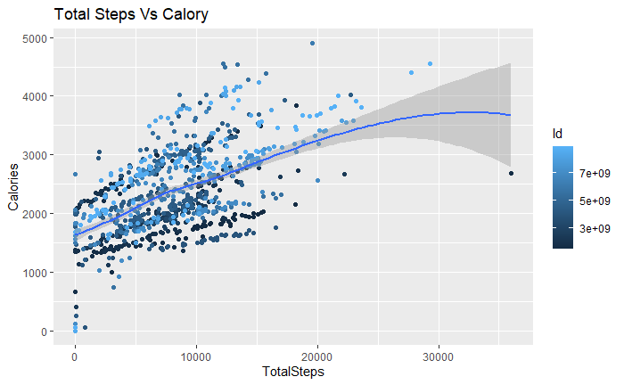

```r
#Total Steps vs Calory
ggplot(data = daily_activity, aes(x=TotalSteps, y=Calories, color=Id)) + geom_point() + geom_smooth(method = "loess") + labs(title = "Total Steps Vs Calory")
```

- Positive Correlation Found i.e. More Steps we walk, more calories will burn.

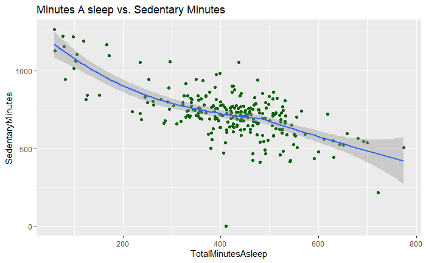

```r
ggplot(data=merged_data, aes(x=TotalMinutesAsleep, y=SedentaryMinutes)) +
geom_point(color='darkgreen') + geom_smooth() +
  labs(title="Minutes A sleep vs. Sedentary Minutes")
```

- Negative Correlation found between Total minute a Sleep and Sedentary Minutes.
- To improve sleep, Sedentary Minutes must be reduced.

# Insights/Findings

- Average total steps per day are 7638 which a little bit less for having health benefits.Compony can encourage users to reach atleast 8000 steps a day to stay fit through marketing campeign.
- If users want to improve their sleep, Bellabeat should consider using app notifications to go to bed.
- To improve sleep, Sedentary Minutes must be reduced.
- If users want to lose Fat, it’s probably a good idea to control daily calorie consumption to become healthy. Bellabeat can suggest some ideas for low-calorie lunch and dinner.

### Thanks for exploring my Bellabeat Case Study.